# Risk Factor Analysis

## Outcome Variable

**Outcome Variable:** ever_swasted

## Predictor Variables

**Intervention Variable:** hhwealth_quart

**Adjustment Set:**

unadjusted

## Stratifying Variables

The analysis was stratified on these variable(s):

- agecat
- studyid
- country

## Data Summary

| agecat | studyid | country | hhwealth_quart | ever_swasted | n_cell | n |
| --- | --- | --- | --- | --- | --- | --- |
| 0-24 months | COHORTS | GUATEMALA | Wealth Q4 | 0 | 442 | 1263 |
| 0-24 months | COHORTS | GUATEMALA | Wealth Q4 | 1 | 34 | 1263 |
| 0-24 months | COHORTS | GUATEMALA | Wealth Q1 | 0 | 229 | 1263 |
| 0-24 months | COHORTS | GUATEMALA | Wealth Q1 | 1 | 15 | 1263 |
| 0-24 months | COHORTS | GUATEMALA | Wealth Q2 | 0 | 242 | 1263 |
| 0-24 months | COHORTS | GUATEMALA | Wealth Q2 | 1 | 16 | 1263 |
| 0-24 months | COHORTS | GUATEMALA | Wealth Q3 | 0 | 257 | 1263 |
| 0-24 months | COHORTS | GUATEMALA | Wealth Q3 | 1 | 28 | 1263 |
| 0-24 months | COHORTS | PHILIPPINES | Wealth Q4 | 0 | 743 | 3044 |
| 0-24 months | COHORTS | PHILIPPINES | Wealth Q4 | 1 | 97 | 3044 |
| 0-24 months | COHORTS | PHILIPPINES | Wealth Q1 | 0 | 590 | 3044 |
| 0-24 months | COHORTS | PHILIPPINES | Wealth Q1 | 1 | 91 | 3044 |
| 0-24 months | COHORTS | PHILIPPINES | Wealth Q2 | 0 | 473 | 3044 |
| 0-24 months | COHORTS | PHILIPPINES | Wealth Q2 | 1 | 67 | 3044 |
| 0-24 months | COHORTS | PHILIPPINES | Wealth Q3 | 0 | 856 | 3044 |
| 0-24 months | COHORTS | PHILIPPINES | Wealth Q3 | 1 | 127 | 3044 |
| 0-6 months | COHORTS | GUATEMALA | Wealth Q4 | 0 | 340 | 1015 |
| 0-6 months | COHORTS | GUATEMALA | Wealth Q4 | 1 | 29 | 1015 |
| 0-6 months | COHORTS | GUATEMALA | Wealth Q1 | 0 | 184 | 1015 |
| 0-6 months | COHORTS | GUATEMALA | Wealth Q1 | 1 | 12 | 1015 |
| 0-6 months | COHORTS | GUATEMALA | Wealth Q2 | 0 | 194 | 1015 |
| 0-6 months | COHORTS | GUATEMALA | Wealth Q2 | 1 | 8 | 1015 |
| 0-6 months | COHORTS | GUATEMALA | Wealth Q3 | 0 | 234 | 1015 |
| 0-6 months | COHORTS | GUATEMALA | Wealth Q3 | 1 | 14 | 1015 |
| 0-6 months | COHORTS | PHILIPPINES | Wealth Q4 | 0 | 765 | 3043 |
| 0-6 months | COHORTS | PHILIPPINES | Wealth Q4 | 1 | 75 | 3043 |
| 0-6 months | COHORTS | PHILIPPINES | Wealth Q1 | 0 | 633 | 3043 |
| 0-6 months | COHORTS | PHILIPPINES | Wealth Q1 | 1 | 47 | 3043 |
| 0-6 months | COHORTS | PHILIPPINES | Wealth Q2 | 0 | 513 | 3043 |
| 0-6 months | COHORTS | PHILIPPINES | Wealth Q2 | 1 | 27 | 3043 |
| 0-6 months | COHORTS | PHILIPPINES | Wealth Q3 | 0 | 921 | 3043 |
| 0-6 months | COHORTS | PHILIPPINES | Wealth Q3 | 1 | 62 | 3043 |
| 6-24 months | COHORTS | GUATEMALA | Wealth Q4 | 0 | 428 | 1154 |
| 6-24 months | COHORTS | GUATEMALA | Wealth Q4 | 1 | 5 | 1154 |
| 6-24 months | COHORTS | GUATEMALA | Wealth Q1 | 0 | 222 | 1154 |
| 6-24 months | COHORTS | GUATEMALA | Wealth Q1 | 1 | 3 | 1154 |
| 6-24 months | COHORTS | GUATEMALA | Wealth Q2 | 0 | 233 | 1154 |
| 6-24 months | COHORTS | GUATEMALA | Wealth Q2 | 1 | 8 | 1154 |
| 6-24 months | COHORTS | GUATEMALA | Wealth Q3 | 0 | 241 | 1154 |
| 6-24 months | COHORTS | GUATEMALA | Wealth Q3 | 1 | 14 | 1154 |
| 6-24 months | COHORTS | PHILIPPINES | Wealth Q4 | 0 | 748 | 2809 |
| 6-24 months | COHORTS | PHILIPPINES | Wealth Q4 | 1 | 23 | 2809 |
| 6-24 months | COHORTS | PHILIPPINES | Wealth Q1 | 0 | 552 | 2809 |
| 6-24 months | COHORTS | PHILIPPINES | Wealth Q1 | 1 | 54 | 2809 |
| 6-24 months | COHORTS | PHILIPPINES | Wealth Q2 | 0 | 464 | 2809 |
| 6-24 months | COHORTS | PHILIPPINES | Wealth Q2 | 1 | 40 | 2809 |
| 6-24 months | COHORTS | PHILIPPINES | Wealth Q3 | 0 | 857 | 2809 |
| 6-24 months | COHORTS | PHILIPPINES | Wealth Q3 | 1 | 71 | 2809 |

The following strata were considered:

- agecat: 0-24 months, studyid: COHORTS, country: GUATEMALA
- agecat: 0-24 months, studyid: COHORTS, country: PHILIPPINES
- agecat: 0-6 months, studyid: COHORTS, country: GUATEMALA
- agecat: 0-6 months, studyid: COHORTS, country: PHILIPPINES
- agecat: 6-24 months, studyid: COHORTS, country: GUATEMALA
- agecat: 6-24 months, studyid: COHORTS, country: PHILIPPINES

### Dropped Strata

Some strata were dropped due to rare outcomes:

- agecat: 6-24 months, studyid: COHORTS, country: GUATEMALA

## Methods Detail

We’re interested in the causal parameters $E[Y_a]$ for all values of $a \in \mathcal{A}$. These parameters represent the mean outcome if, possibly contrary to fact, we intervened to set all units to have $A=a$. Under the randomization and positivity assumptions, these are identified by the statistical parameters $\psi_a=E_W[E_{Y|A,W}(Y|A=a,W)]$. In addition, we’re interested in the mean of $Y$, $E[Y]$ under no intervention (the observed mean). We will estimate these parameters by using SuperLearner to fit the relevant likelihood factors – $E_{Y|A,W}(Y|A=a,W)$ and $p(A=a|W)$, and then updating our likelihood fit using a joint TMLE.

For unadjusted analyses ($W=\{\}$), initial likelihoods were estimated using Lrnr_glm to estimate the simple $E(Y|A)$ and Lrnr_mean to estimate $p(A)$. For adjusted analyses, a small library containing Lrnr_glmnet, Lrnr_xgboost, and Lrnr_mean was used.

Having estimated these parameters, we will then use the delta method to estimate relative risks and attributable risks relative to a prespecified baseline level of $A$.

# Results Detail

## Results Plots

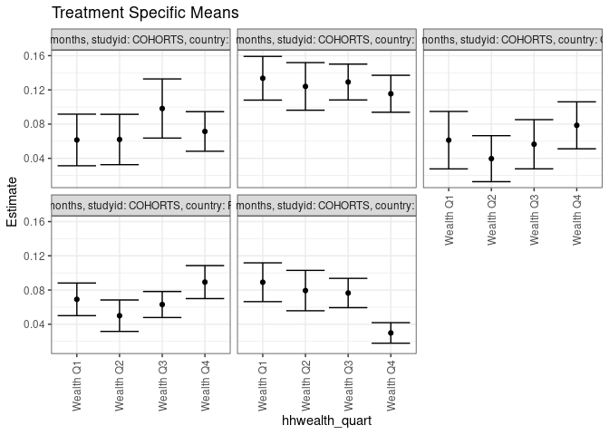

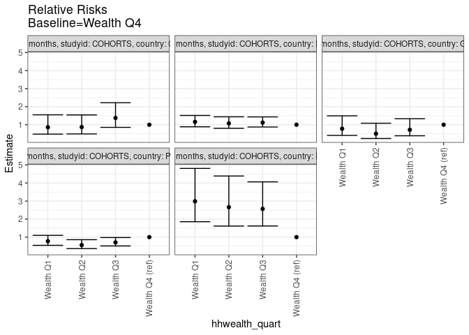

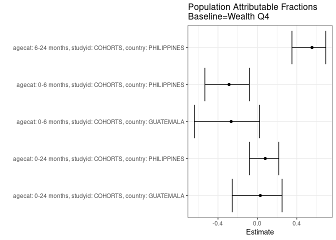

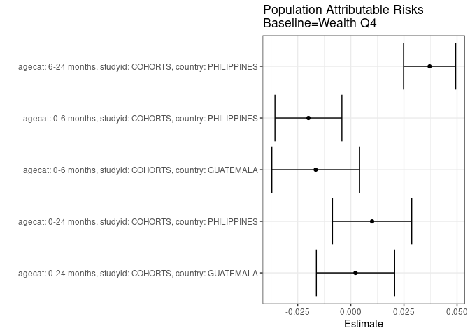

## Results Table

### Parameter: TSM

| agecat | studyid | country | intervention_level | baseline_level | estimate | ci_lower | ci_upper |
| --- | --- | --- | --- | --- | --- | --- | --- |
| 0-24 months | COHORTS | GUATEMALA | Wealth Q4 | NA | 0.0714286 | 0.0482834 | 0.0945737 |
| 0-24 months | COHORTS | GUATEMALA | Wealth Q1 | NA | 0.0614754 | 0.0313246 | 0.0916262 |
| 0-24 months | COHORTS | GUATEMALA | Wealth Q2 | NA | 0.0620155 | 0.0325741 | 0.0914569 |
| 0-24 months | COHORTS | GUATEMALA | Wealth Q3 | NA | 0.0982456 | 0.0636757 | 0.1328155 |
| 0-24 months | COHORTS | PHILIPPINES | Wealth Q4 | NA | 0.1154762 | 0.0938599 | 0.1370925 |
| 0-24 months | COHORTS | PHILIPPINES | Wealth Q1 | NA | 0.1336270 | 0.1080679 | 0.1591861 |
| 0-24 months | COHORTS | PHILIPPINES | Wealth Q2 | NA | 0.1240741 | 0.0962643 | 0.1518838 |
| 0-24 months | COHORTS | PHILIPPINES | Wealth Q3 | NA | 0.1291963 | 0.1082249 | 0.1501678 |
| 0-6 months | COHORTS | GUATEMALA | Wealth Q4 | NA | 0.0785908 | 0.0511206 | 0.1060609 |
| 0-6 months | COHORTS | GUATEMALA | Wealth Q1 | NA | 0.0612245 | 0.0276447 | 0.0948042 |
| 0-6 months | COHORTS | GUATEMALA | Wealth Q2 | NA | 0.0396040 | 0.0126960 | 0.0665119 |
| 0-6 months | COHORTS | GUATEMALA | Wealth Q3 | NA | 0.0564516 | 0.0277136 | 0.0851896 |
| 0-6 months | COHORTS | PHILIPPINES | Wealth Q4 | NA | 0.0892857 | 0.0699988 | 0.1085726 |
| 0-6 months | COHORTS | PHILIPPINES | Wealth Q1 | NA | 0.0691176 | 0.0500496 | 0.0881857 |
| 0-6 months | COHORTS | PHILIPPINES | Wealth Q2 | NA | 0.0500000 | 0.0316148 | 0.0683852 |
| 0-6 months | COHORTS | PHILIPPINES | Wealth Q3 | NA | 0.0630722 | 0.0478732 | 0.0782712 |
| 6-24 months | COHORTS | PHILIPPINES | Wealth Q4 | NA | 0.0298314 | 0.0178210 | 0.0418418 |
| 6-24 months | COHORTS | PHILIPPINES | Wealth Q1 | NA | 0.0891089 | 0.0664216 | 0.1117962 |
| 6-24 months | COHORTS | PHILIPPINES | Wealth Q2 | NA | 0.0793651 | 0.0557620 | 0.1029682 |
| 6-24 months | COHORTS | PHILIPPINES | Wealth Q3 | NA | 0.0765086 | 0.0594036 | 0.0936136 |

### Parameter: E(Y)

| agecat | studyid | country | intervention_level | baseline_level | estimate | ci_lower | ci_upper |
| --- | --- | --- | --- | --- | --- | --- | --- |
| 0-24 months | COHORTS | GUATEMALA | NA | NA | 0.0736342 | 0.0592247 | 0.0880437 |
| 0-24 months | COHORTS | PHILIPPINES | NA | NA | 0.1254928 | 0.1137225 | 0.1372631 |
| 0-6 months | COHORTS | GUATEMALA | NA | NA | 0.0620690 | 0.0472181 | 0.0769198 |
| 0-6 months | COHORTS | PHILIPPINES | NA | NA | 0.0693395 | 0.0603122 | 0.0783667 |
| 6-24 months | COHORTS | PHILIPPINES | NA | NA | 0.0669277 | 0.0576848 | 0.0761707 |

### Parameter: RR

| agecat | studyid | country | intervention_level | baseline_level | estimate | ci_lower | ci_upper |
| --- | --- | --- | --- | --- | --- | --- | --- |
| 0-24 months | COHORTS | GUATEMALA | Wealth Q4 | Wealth Q4 | 1.0000000 | 1.0000000 | 1.0000000 |
| 0-24 months | COHORTS | GUATEMALA | Wealth Q1 | Wealth Q4 | 0.8606557 | 0.4781226 | 1.5492433 |
| 0-24 months | COHORTS | GUATEMALA | Wealth Q2 | Wealth Q4 | 0.8682171 | 0.4886553 | 1.5426025 |
| 0-24 months | COHORTS | GUATEMALA | Wealth Q3 | Wealth Q4 | 1.3754386 | 0.8525108 | 2.2191288 |
| 0-24 months | COHORTS | PHILIPPINES | Wealth Q4 | Wealth Q4 | 1.0000000 | 1.0000000 | 1.0000000 |
| 0-24 months | COHORTS | PHILIPPINES | Wealth Q1 | Wealth Q4 | 1.1571824 | 0.8854652 | 1.5122799 |
| 0-24 months | COHORTS | PHILIPPINES | Wealth Q2 | Wealth Q4 | 1.0744559 | 0.8023494 | 1.4388439 |
| 0-24 months | COHORTS | PHILIPPINES | Wealth Q3 | Wealth Q4 | 1.1188136 | 0.8732790 | 1.4333837 |
| 0-6 months | COHORTS | GUATEMALA | Wealth Q4 | Wealth Q4 | 1.0000000 | 1.0000000 | 1.0000000 |
| 0-6 months | COHORTS | GUATEMALA | Wealth Q1 | Wealth Q4 | 0.7790289 | 0.4065347 | 1.4928270 |
| 0-6 months | COHORTS | GUATEMALA | Wealth Q2 | Wealth Q4 | 0.5039263 | 0.2347135 | 1.0819217 |
| 0-6 months | COHORTS | GUATEMALA | Wealth Q3 | Wealth Q4 | 0.7182981 | 0.3873644 | 1.3319556 |
| 0-6 months | COHORTS | PHILIPPINES | Wealth Q4 | Wealth Q4 | 1.0000000 | 1.0000000 | 1.0000000 |
| 0-6 months | COHORTS | PHILIPPINES | Wealth Q1 | Wealth Q4 | 0.7741176 | 0.5453008 | 1.0989497 |
| 0-6 months | COHORTS | PHILIPPINES | Wealth Q2 | Wealth Q4 | 0.5600000 | 0.3655768 | 0.8578225 |
| 0-6 months | COHORTS | PHILIPPINES | Wealth Q3 | Wealth Q4 | 0.7064090 | 0.5111031 | 0.9763462 |
| 6-24 months | COHORTS | PHILIPPINES | Wealth Q4 | Wealth Q4 | 1.0000000 | 1.0000000 | 1.0000000 |
| 6-24 months | COHORTS | PHILIPPINES | Wealth Q1 | Wealth Q4 | 2.9870857 | 1.8551021 | 4.8098056 |
| 6-24 months | COHORTS | PHILIPPINES | Wealth Q2 | Wealth Q4 | 2.6604555 | 1.6127752 | 4.3887229 |
| 6-24 months | COHORTS | PHILIPPINES | Wealth Q3 | Wealth Q4 | 2.5647020 | 1.6182129 | 4.0647904 |

### Parameter: PAR

| agecat | studyid | country | intervention_level | baseline_level | estimate | ci_lower | ci_upper |
| --- | --- | --- | --- | --- | --- | --- | --- |
| 0-24 months | COHORTS | GUATEMALA | Wealth Q4 | NA | 0.0022056 | -0.0162211 | 0.0206324 |
| 0-24 months | COHORTS | PHILIPPINES | Wealth Q4 | NA | 0.0100166 | -0.0086360 | 0.0286692 |
| 0-6 months | COHORTS | GUATEMALA | Wealth Q4 | NA | -0.0165218 | -0.0371734 | 0.0041297 |
| 0-6 months | COHORTS | PHILIPPINES | Wealth Q4 | NA | -0.0199462 | -0.0356977 | -0.0041948 |
| 6-24 months | COHORTS | PHILIPPINES | Wealth Q4 | NA | 0.0370963 | 0.0248287 | 0.0493640 |

### Parameter: PAF

| agecat | studyid | country | intervention_level | baseline_level | estimate | ci_lower | ci_upper |
| --- | --- | --- | --- | --- | --- | --- | --- |
| 0-24 months | COHORTS | GUATEMALA | Wealth Q4 | NA | 0.0299539 | -0.2554607 | 0.2504828 |
| 0-24 months | COHORTS | PHILIPPINES | Wealth Q4 | NA | 0.0798180 | -0.0813311 | 0.2169513 |
| 0-6 months | COHORTS | GUATEMALA | Wealth Q4 | NA | -0.2661849 | -0.6400766 | 0.0224700 |
| 0-6 months | COHORTS | PHILIPPINES | Wealth Q4 | NA | -0.2876608 | -0.5331048 | -0.0815114 |
| 6-24 months | COHORTS | PHILIPPINES | Wealth Q4 | NA | 0.5542746 | 0.3507122 | 0.6940169 |